# R Notebook

Ryan E. Kelly CS 668 - Analytics Capstone Prof Krystyn Gutu 15 OCTOBER 2024 #CODE REVIEW 1

SECTION I. Obtaining our Datasets

(Objective section from Project Overview Statement)

Objective 1: Data Acquisition and Preparation - Outcome: Obtain, clean, and prepare all necessary datasets, including GDP, unemployment rates, CPI, and population movement data, for forecasting tax revenues. - Time Frame: Completed within the first month. - Measure: Datasets will be processed, cleaned, and prepared for modeling, verified by checking for missing values, formatting, and ensuring time alignment across indicators. - Action: Data will be sourced from the U.S. Bureau of Economic Analysis (BEA), Bureau of Labor Statistics (BLS), and U.S. Census Bureau, and pre-processed for time series forecasting.

Notes:

For select datasets, I have registered a personal API key with the Department of Labor and Department of Commerce for data access. The only two datasets I had to import manually was for Census Data and NYS tax revenues. US Census has an API, but the requests are limited and the data was not up date. As a result, I manually pulled the data from their website and read it into R. For each dataset, I list the source URL as reference.

At this point, I am satisfied with the datasets I have pulled and will begin the next phase of satisfying the remaining objective requirements by building three time series models.

When applicable, I have converted data to conform to the New York State fiscal year. In some instances, this was not available - however - the standard 12 month average between fiscal year and calendar year line up closely. I will use calendar year in the model for the values of CPI and population change. The remaining will be in fiscal year.

You are welcome to use the API keys to test the data pulls.

RK

15 October 2024

```r
# Packages for API access and JSON handling
library(httr)
library(jsonlite)
```

# DATASET 1 - New York State GDP (Current Dollar)

Source: US Department of Commerce - Bureau of Economic Analysis https://www.bea.gov/data/gdp/gdp-state

https://apps.bea.gov/iTable/?reqid=99&step=1 (REFERENCES FOR TABLE CODES) Table code: CAGDP2 NY State Code: 36000

```r
# Set up BEA API key and URL for GDP data (Current-Dollar GDP for NYS)
bea_api_key <- "D4DCEE44-9DAF-4560-9E02-3F1DE64F5165"

# API Request Format
bea_api_url <- paste0("https://apps.bea.gov/api/data/?&UserID=", bea_api_key,
                      "&method=GetData&datasetname=Regional&TableName=CAGDP2&GeoFips=36000&LineCode=1&Year=ALL&ResultFormat=JSON")

# API Call
gdp_response <- GET(bea_api_url)

if (status_code(gdp_response) == 200) {
  message("API request successful.")
  # Parse Data
  gdp_content <- content(gdp_response, as = "text")
  ny_gdp_data <- fromJSON(gdp_content)$BEAAPI$Results$Data
} else {
  stop("API request failed. Status code: ", status_code(gdp_response))
}
```

```
API request successful.
No encoding supplied: defaulting to UTF-8.
```

```r
head(ny_gdp_data)
```

|  | Code | GeoFips | GeoName | TimePeriod | CL_UNIT | UNIT_MULT | DataValue |
| --- | --- | --- | --- | --- | --- | --- | --- |
| 1 | CAGDP2-1 | 36000 | New York | 2017 | Thousands of dollars | 3 | 1624800665 |
| 2 | CAGDP2-1 | 36000 | New York | 2018 | Thousands of dollars | 3 | 1710665609 |
| 3 | CAGDP2-1 | 36000 | New York | 2019 | Thousands of dollars | 3 | 1793261344 |
| 4 | CAGDP2-1 | 36000 | New York | 2020 | Thousands of dollars | 3 | 1766857434 |
| 5 | CAGDP2-1 | 36000 | New York | 2021 | Thousands of dollars | 3 | 1911345800 |
| 6 | CAGDP2-1 | 36000 | New York | 2022 | Thousands of dollars | 3 | 2048402630 |

```r
str(ny_gdp_data)
```

```
'data.frame':   6 obs. of  7 variables:
 $ Code      : chr  "CAGDP2-1" "CAGDP2-1" "CAGDP2-1" "CAGDP2-1" ...
 $ GeoFips   : chr  "36000" "36000" "36000" "36000" ...
 $ GeoName   : chr  "New York" "New York" "New York" "New York" ...
 $ TimePeriod: chr  "2017" "2018" "2019" "2020" ...
 $ CL_UNIT   : chr  "Thousands of dollars" "Thousands of dollars" "Thousands of dollars" "Thousands of dollars" ...
 $ UNIT_MULT : chr  "3" "3" "3" "3" ...
 $ DataValue : chr  "1624800665" "1710665609" "1793261344" "1766857434" ...
```

```r
summary(ny_gdp_data)
```

```
     Code             GeoFips            GeoName           TimePeriod          CL_UNIT
 Length:6           Length:6           Length:6           Length:6           Length:6
 Class :character   Class :character   Class :character   Class :character   Class :character
 Mode  :character   Mode  :character   Mode  :character   Mode  :character   Mode  :character
  UNIT_MULT          DataValue
 Length:6           Length:6
 Class :character   Class :character
 Mode  :character   Mode  :character
```

```r
ny_gdp_df <- as.data.frame(ny_gdp_data)
colnames(ny_gdp_df) <- c("series_id", "geofips", "region", "year", "units", "industry", "GDP_value")

# Adjust GDP values for real dollars
ny_gdp_df$GDP_value <- as.numeric(ny_gdp_df$GDP_value) * 1000
ny_gdp_df$year <- as.numeric(ny_gdp_df$year)

ny_gdp_df$fiscal_year <- paste(ny_gdp_df$year - 1, ny_gdp_df$year, sep = "-")
```

```r
View(ny_gdp_df)
```

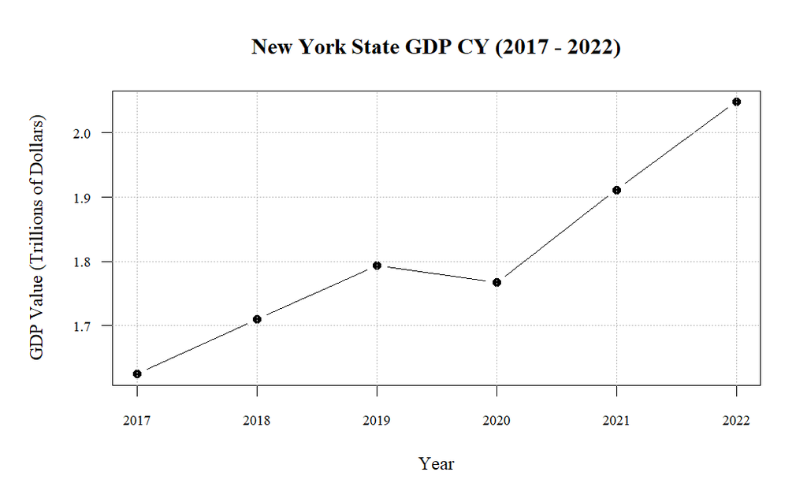

```r
windowsFonts(A = windowsFont("Times New Roman"))
par(family = "A", mar = c(5, 5, 4, 2) + 0.1)

year_range <- paste(min(ny_gdp_df$year), max(ny_gdp_df$year), sep = " - ")

plot(
  ny_gdp_df$year, ny_gdp_df$GDP_value / 1e12,
  type = "b",
  col = "black",
  xlab = "Year",
  ylab = "GDP Value (Trillions of Dollars)",
  main = paste("New York State GDP CY (", year_range, ")", sep = ""),
  pch = 19,
  lwd = 1,
  las = 1,
  cex.axis = 0.8,
  cex.lab = 1
)

grid(nx = NULL, ny = NULL, col = "gray", lty = "dotted")
```

```r
NA
NA
```

# DATASET 2 - New York State Unemployment Data

Source: US Department of Labor - Bureau of Labor Statistics https://data.bls.gov/pdq/SurveyOutputServlet

```r
# Set up BLS API key and series ID for New York State unemployment
bls_api_key <- "85f2b89f6fd64218a8ef61270b0e8dc1"
ny_unemployment_series_id <- "LAUST360000000000003"

# API Request Format
bls_api_url <- paste0("https://api.bls.gov/publicAPI/v2/timeseries/data/",
                      ny_unemployment_series_id,
                      "?registrationkey=", bls_api_key,
                      "&startyear=2010&endyear=2023")

# API Call
unemployment_response <- GET(bls_api_url)

# Check if the API request was successful
if (status_code(unemployment_response) == 200) {
  message("API request successful.")
  # Parse data
  unemployment_content <- content(unemployment_response, as = "parsed", type = "application/json")
  ny_unemployment_data <- Filter(function(x) !is.null(x$year) &&
                                              !is.null(x$period) &&
                                              !is.null(x$periodName) &&
                                              !is.null(x$value),
                                 unemployment_content$Results$series[[1]]$data)
} else {
  stop("API request failed. Status code: ", status_code(unemployment_response))
}
```

```
API request successful.
```

```r
head(ny_unemployment_data)
```

```
[[1]]
[[1]]$year
[1] "2023"

[[1]]$period
[1] "M12"

[[1]]$periodName
[1] "December"

[[1]]$value
[1] "4.4"

[[1]]$footnotes
[[1]]$footnotes[[1]]
named list()



[[2]]
[[2]]$year
[1] "2023"

[[2]]$period
[1] "M11"

[[2]]$periodName
[1] "November"

[[2]]$value
[1] "4.2"

[[2]]$footnotes
[[2]]$footnotes[[1]]
named list()



[[3]]
[[3]]$year
```

[output cut: 56 more lines]

```
[[6]]$year
[1] "2023"

[[6]]$period
[1] "M07"

[[6]]$periodName
[1] "July"

[[6]]$value
[1] "4.2"

[[6]]$footnotes
[[6]]$footnotes[[1]]
named list()
```

```r
View(ny_unemployment_data)
```

```r
# Convert to a dataframe and assign numeric types
ny_unemployment_df <- data.frame(
  year = as.numeric(unlist(lapply(ny_unemployment_data, function(x) x$year))),
  period = unlist(lapply(ny_unemployment_data, function(x) x$period)),
  period_name = unlist(lapply(ny_unemployment_data, function(x) x$periodName)),
  unemployment_rate = as.numeric(unlist(lapply(ny_unemployment_data, function(x) x$value)))
)
```

```r
# Remove "M13" summary data and calculate fiscal year
ny_unemployment_df <- subset(ny_unemployment_df, period != "M13")
ny_unemployment_df$fiscal_year <- ifelse(ny_unemployment_df$period %in% paste0("M", sprintf("%02d", 1:3)),
                                         ny_unemployment_df$year - 1, ny_unemployment_df$year)

# Calculate averages for calendar and fiscal years in one go
ny_annual_unemployment <- aggregate(unemployment_rate ~ year, data = ny_unemployment_df, FUN = mean)
colnames(ny_annual_unemployment)[2] <- "unemployment_CY"

ny_fiscal_unemployment <- aggregate(unemployment_rate ~ fiscal_year, data = ny_unemployment_df, FUN = mean)
colnames(ny_fiscal_unemployment)[2] <- "unemployment_FY"

# Combine calendar and fiscal year data into one dataframe
ny_unemployment <- merge(ny_annual_unemployment, ny_fiscal_unemployment,
                         by.x = "year", by.y = "fiscal_year", all = TRUE)
```

```r
View(ny_unemployment)
```

```r
windowsFonts(A = windowsFont("Times New Roman"))
par(family = "A", mar = c(5, 5, 4, 2) + 0.1)

# Plot Calendar Year data
plot(
  ny_unemployment$year,
  ny_unemployment$unemployment_CY,
  type = "o",
  col = "black",
  lwd = 1,
  pch = 19,
  xaxt = "n",
  yaxt = "n",
  ylab = "Average Unemployment Rate (%)",
  xlab = "Year",
  main = "New York State Average Unemployment Rate CY (2010 - 2023)"
)

axis(1, at = ny_unemployment$year, labels = ny_unemployment$year, las = 2)
```

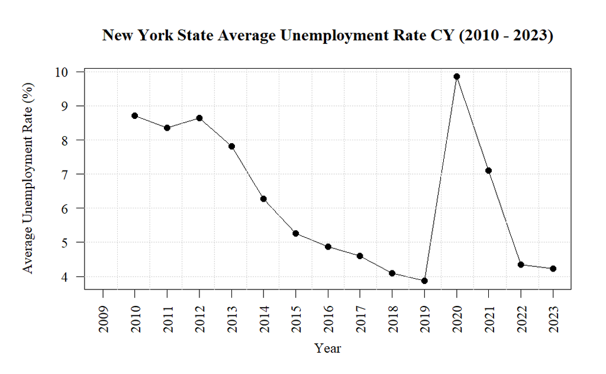

```r
axis(2, las = 1)

grid(nx = length(ny_unemployment$year), ny = NULL, col = "lightgray", lty = "dotted")
```

```r
# Ensure Times New Roman font and adjust margins
windowsFonts(A = windowsFont("Times New Roman"))
par(family = "A", mar = c(5, 5, 4, 2) + 0.1)

# Plot Fiscal Year data
plot(
  ny_unemployment$year,
  ny_unemployment$unemployment_FY,
  type = "o",
  col = "black",
  lwd = 1,
  pch = 19,
  xaxt = "n",
  yaxt = "n",
  ylab = "Average Unemployment Rate (%)",
  xlab = "Fiscal Year",
  main = "New York State Average Unemployment Rate FY (2010 - 2023)"
)

axis(1, at = ny_unemployment$year, labels = ny_unemployment$year, las = 2)
```

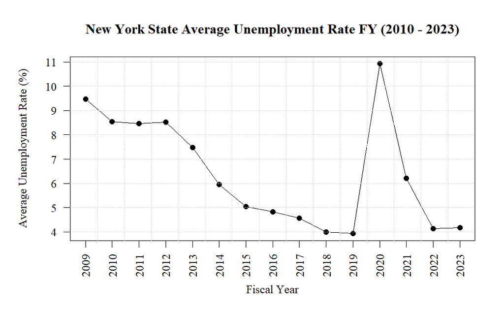

```r
axis(2, las = 1)

grid(nx = length(ny_unemployment$year), ny = NULL, col = "lightgray", lty = "dotted")
```

DATASET #3 - CPI Data - North Eastern US Source: US Department of Labor - Bureau of Labor Statistics https://www.bls.gov/regions/mid-atlantic/news-release/consumerpriceindex_northeast.htm

https://data.bls.gov/timeseries/CUUR0100SA0?amp%253bdata_tool=XGtable&output_view=data&include_graphs=true

```r
# Set up BLS API key and series ID for Northeast region CPI (All Items, Urban Consumers)
bls_api_key <- "85f2b89f6fd64218a8ef61270b0e8dc1"
cpi_series_id <- "CUUR0100SA0"

# API Request Format
cpi_api_url <- paste0("https://api.bls.gov/publicAPI/v2/timeseries/data/",
                      cpi_series_id,
                      "?registrationkey=", bls_api_key,
                      "&startyear=2010&endyear=2023")

# API Call
cpi_response <- GET(cpi_api_url)

if (status_code(cpi_response) == 200) {
  message("API request successful.")
  # Parse and filter the data
  cpi_content <- content(cpi_response, as = "parsed", type = "application/json")
  northeast_cpi_data <- Filter(function(x) !is.null(x$year) && !is.null(x$period) &&
                                            !is.null(x$periodName) && !is.null(x$value),
                               cpi_content$Results$series[[1]]$data)
} else {
  stop("API request failed. Status code: ", status_code(cpi_response))
}
```

```
API request successful.
```

```r
head(northeast_cpi_data)
```

```
[[1]]
[[1]]$year
[1] "2023"

[[1]]$period
[1] "M12"

[[1]]$periodName
[1] "December"

[[1]]$value
[1] "316.143"

[[1]]$footnotes
[[1]]$footnotes[[1]]
named list()



[[2]]
[[2]]$year
[1] "2023"

[[2]]$period
[1] "M11"

[[2]]$periodName
[1] "November"

[[2]]$value
[1] "316.252"

[[2]]$footnotes
[[2]]$footnotes[[1]]
named list()



[[3]]
[[3]]$year
```

[output cut: 56 more lines]

```
[[6]]$year
[1] "2023"

[[6]]$period
[1] "M07"

[[6]]$periodName
[1] "July"

[[6]]$value
[1] "313.952"

[[6]]$footnotes
[[6]]$footnotes[[1]]
named list()
```

```r
summary(northeast_cpi_data)
```

```
       Length Class  Mode
  [1,] 5      -none- list
  [2,] 5      -none- list
  [3,] 5      -none- list
  [4,] 5      -none- list
  [5,] 5      -none- list
  [6,] 5      -none- list
  [7,] 5      -none- list
  [8,] 5      -none- list
  [9,] 5      -none- list
 [10,] 5      -none- list
 [11,] 5      -none- list
 [12,] 5      -none- list
 [13,] 5      -none- list
 [14,] 5      -none- list
```

[output cut: 154 more lines]

```r
View(northeast_cpi_data)
```

```r
northeast_cpi_df <- data.frame(
  year = as.numeric(unlist(lapply(northeast_cpi_data, function(x) x$year))),
  period = unlist(lapply(northeast_cpi_data, function(x) x$period)),
  period_name = unlist(lapply(northeast_cpi_data, function(x) x$periodName)),
  cpi_index = as.numeric(unlist(lapply(northeast_cpi_data, function(x) x$value)))
)
```

```r
# Aggregate for Calendar Year
calendar_year_cpi <- aggregate(cpi_index ~ year, data = northeast_cpi_df, FUN = mean)

# Aggregate for Fiscal Year (April 1 - March 31)
fiscal_year_cpi <- aggregate(cpi_index ~ year,
                             data = subset(northeast_cpi_df, period_name %in% c("April", "May", "June", "July", "August", "September", "October", "November", "December", "January", "February", "March")),
                             FUN = function(x) mean(x, na.rm = TRUE))

# Adjust fiscal year labels to start in previous year (e.g., Fiscal Year 2022 becomes 2021-2022)
fiscal_year_cpi$year <- fiscal_year_cpi$year - 1

# Merge Calendar Year and Fiscal Year data into a single dataframe
ne_cpi_data <- merge(calendar_year_cpi, fiscal_year_cpi, by = "year", all = TRUE)
colnames(ne_cpi_data) <- c("year", "cpi_calendar_year", "cpi_fiscal_year")
```

```r
head(ne_cpi_data)
```

|  | year | cpi_calendar_year | cpi_fiscal_year |
| --- | --- | --- | --- |
| 1 | 2009 | NA | 233.8676 |
| 2 | 2010 | 233.8676 | 240.9973 |
| 3 | 2011 | 240.9973 | 245.6980 |
| 4 | 2012 | 245.6980 | 249.0375 |
| 5 | 2013 | 249.0375 | 252.4627 |
| 6 | 2014 | 252.4627 | 252.1849 |

```r
summary(ne_cpi_data)
```

```
      year      cpi_calendar_year cpi_fiscal_year
 Min.   :2009   Min.   :233.9     Min.   :233.9
 1st Qu.:2012   1st Qu.:249.8     1st Qu.:249.8
 Median :2016   Median :257.2     Median :257.2
 Mean   :2016   Mean   :264.1     Mean   :264.1
 3rd Qu.:2020   3rd Qu.:272.0     3rd Qu.:272.0
 Max.   :2023   Max.   :313.8     Max.   :313.8
                NA's   :1         NA's   :1
```

```r
View(ne_cpi_data)
```

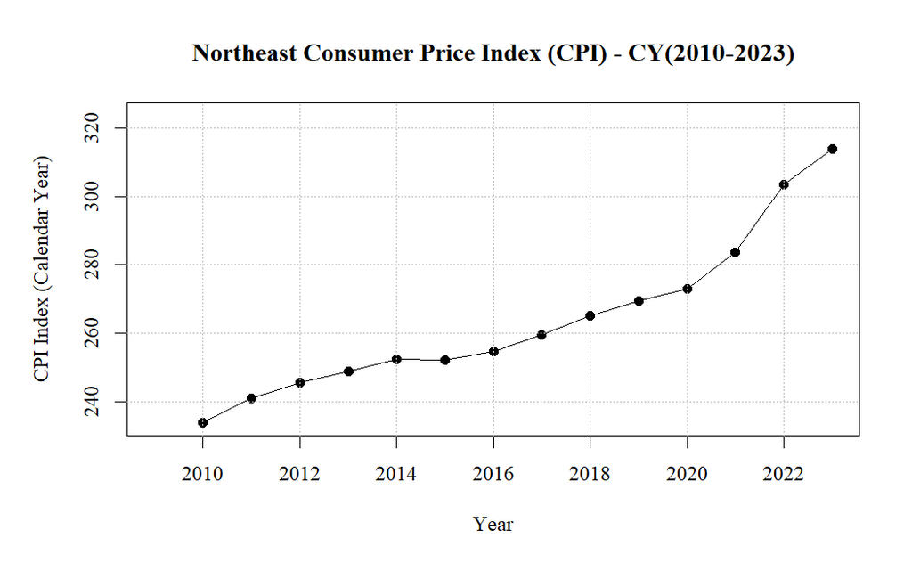

```r
windowsFonts(A = windowsFont("Times New Roman"))
par(family = "A", mar = c(5, 5, 4, 2) + 0.1)
cpi_range <- range(ne_cpi_data$cpi_calendar_year, na.rm = TRUE)
ylim_upper <- cpi_range[2] + 10

plot(
  ne_cpi_data$year, ne_cpi_data$cpi_calendar_year, type = "o",
  col = "black", pch = 19, lty = 1, lwd = 1,
  xlab = "Year", ylab = "CPI Index (Calendar Year)",
  main = "Northeast Consumer Price Index (CPI) - CY(2010-2023)",
  ylim = c(cpi_range[1], ylim_upper)
)

grid(nx = NULL, ny = NULL, col = "gray", lty = "dotted")
```

```r
NA
NA
```

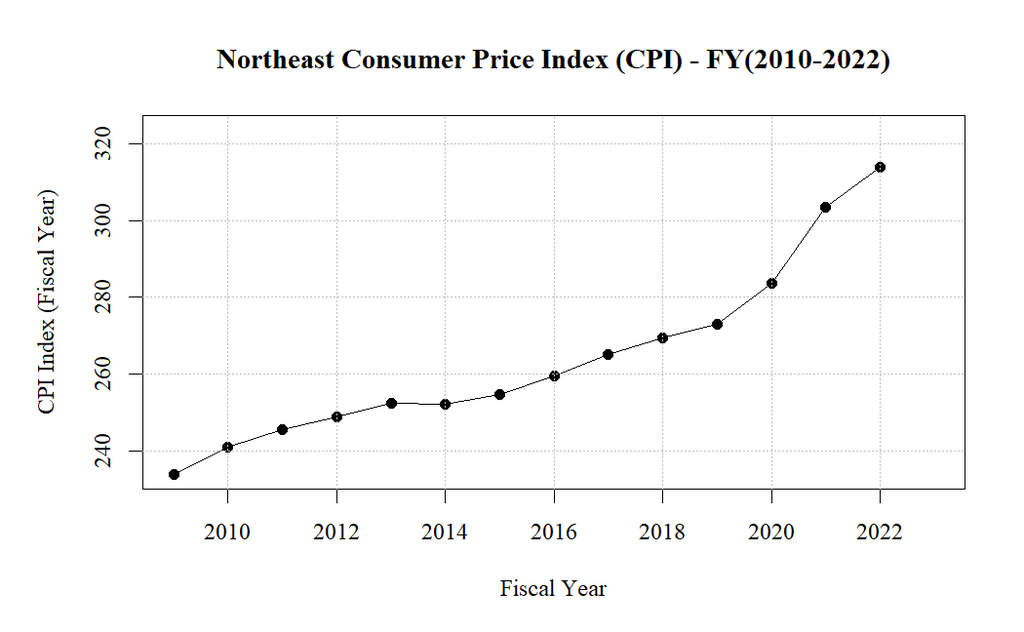

```r
windowsFonts(A = windowsFont("Times New Roman"))
par(family = "A", mar = c(5, 5, 4, 2) + 0.1)

cpi_range_fy <- range(ne_cpi_data$cpi_fiscal_year, na.rm = TRUE)
ylim_upper_fy <- cpi_range_fy[2] + 10

plot(
  ne_cpi_data$year, ne_cpi_data$cpi_fiscal_year, type = "o",
  col = "black", pch = 19, lty = 1, lwd = 1,
  xlab = "Fiscal Year", ylab = "CPI Index (Fiscal Year)",
  main = "Northeast Consumer Price Index (CPI) - FY(2010-2022)",
  ylim = c(cpi_range_fy[1], ylim_upper_fy)
)

grid(nx = NULL, ny = NULL, col = "gray", lty = "dotted")
```

#DATASET 4 - Census Data - New York State Population Movement https://www.census.gov/data/datasets/time-series/demo/popest/2020s-state-total.html Manual Entry

```r
file_path <- "C:/Users/Ryane/Proton Drive/R Project Files/NY-NST-EST2023-POPCHG2020_2023.csv"
ny_pop_data <- read.csv(file_path)

# View the first few rows
head(ny_pop_data)
```

|  | SUMLEV | REGION | DIVISION | STATE | NAME | ESTIMATESBASE2020 | POPESTIMATE2020 | POPESTIMATE2021 | POPESTIMATE2022 | POPESTIMATE2023 | NPOPCHG_2020 | NPOPCHG_2021 | NPOPCHG_2022 | NPOPCHG_2023 | PPOPCHG_2020 | PPOPCHG_2021 | PPOPCHG_2022 | PPOPCHG_2023 | NRANK_ESTBASE2020 | NRANK_POPEST2020 | NRANK_POPEST2021 | NRANK_POPEST2022 | NRANK_POPEST2023 | NRANK_NPCHG2020 | NRANK_NPCHG2021 | NRANK_NPCHG2022 | NRANK_NPCHG2023 | NRANK_PPCHG2020 | NRANK_PPCHG2021 | … |
| --- | --- | --- | --- | --- | --- | --- | --- | --- | --- | --- | --- | --- | --- | --- | --- | --- | --- | --- | --- | --- | --- | --- | --- | --- | --- | --- | --- | --- | --- | --- |
| 1 | 40 | 1 | 2 | 36 | New York | 20202320 | 20104710 | 19854526 | 19673200 | 19571216 | -97610 | -250184 | -181326 | -101984 | -0.4831623 | -1.244405 | -0.9132729 | -0.5183905 | 4 | 4 | 4 | 4 | 4 | 51 | 50 | 51 | 51 | 48 | 51 | … |

```r
NA
```

```r
summary(ny_pop_data)
```

```
     SUMLEV       REGION     DIVISION     STATE        NAME           ESTIMATESBASE2020
 Min.   :40   Min.   :1   Min.   :2   Min.   :36   Length:1           Min.   :20202320
 1st Qu.:40   1st Qu.:1   1st Qu.:2   1st Qu.:36   Class :character   1st Qu.:20202320
 Median :40   Median :1   Median :2   Median :36   Mode  :character   Median :20202320
 Mean   :40   Mean   :1   Mean   :2   Mean   :36                      Mean   :20202320
 3rd Qu.:40   3rd Qu.:1   3rd Qu.:2   3rd Qu.:36                      3rd Qu.:20202320
 Max.   :40   Max.   :1   Max.   :2   Max.   :36                      Max.   :20202320
 POPESTIMATE2020    POPESTIMATE2021    POPESTIMATE2022    POPESTIMATE2023     NPOPCHG_2020
 Min.   :20104710   Min.   :19854526   Min.   :19673200   Min.   :19571216   Min.   :-97610
 1st Qu.:20104710   1st Qu.:19854526   1st Qu.:19673200   1st Qu.:19571216   1st Qu.:-97610
 Median :20104710   Median :19854526   Median :19673200   Median :19571216   Median :-97610
 Mean   :20104710   Mean   :19854526   Mean   :19673200   Mean   :19571216   Mean   :-97610
 3rd Qu.:20104710   3rd Qu.:19854526   3rd Qu.:19673200   3rd Qu.:19571216   3rd Qu.:-97610
 Max.   :20104710   Max.   :19854526   Max.   :19673200   Max.   :19571216   Max.   :-97610
  NPOPCHG_2021      NPOPCHG_2022      NPOPCHG_2023      PPOPCHG_2020      PPOPCHG_2021
 Min.   :-250184   Min.   :-181326   Min.   :-101984   Min.   :-0.4832   Min.   :-1.244
 1st Qu.:-250184   1st Qu.:-181326   1st Qu.:-101984   1st Qu.:-0.4832   1st Qu.:-1.244
 Median :-250184   Median :-181326   Median :-101984   Median :-0.4832   Median :-1.244
 Mean   :-250184   Mean   :-181326   Mean   :-101984   Mean   :-0.4832   Mean   :-1.244
 3rd Qu.:-250184   3rd Qu.:-181326   3rd Qu.:-101984   3rd Qu.:-0.4832   3rd Qu.:-1.244
 Max.   :-250184   Max.   :-181326   Max.   :-101984   Max.   :-0.4832   Max.   :-1.244
  PPOPCHG_2022      PPOPCHG_2023     NRANK_ESTBASE2020 NRANK_POPEST2020 NRANK_POPEST2021
 Min.   :-0.9133   Min.   :-0.5184   Min.   :4         Min.   :4        Min.   :4
 1st Qu.:-0.9133   1st Qu.:-0.5184   1st Qu.:4         1st Qu.:4        1st Qu.:4
 Median :-0.9133   Median :-0.5184   Median :4         Median :4        Median :4
 Mean   :-0.9133   Mean   :-0.5184   Mean   :4         Mean   :4        Mean   :4
 3rd Qu.:-0.9133   3rd Qu.:-0.5184   3rd Qu.:4         3rd Qu.:4        3rd Qu.:4
 Max.   :-0.9133   Max.   :-0.5184   Max.   :4         Max.   :4        Max.   :4
 NRANK_POPEST2022 NRANK_POPEST2023 NRANK_NPCHG2020 NRANK_NPCHG2021 NRANK_NPCHG2022
 Min.   :4        Min.   :4        Min.   :51      Min.   :50      Min.   :51
 1st Qu.:4        1st Qu.:4        1st Qu.:51      1st Qu.:50      1st Qu.:51
 Median :4        Median :4        Median :51      Median :50      Median :51
 Mean   :4        Mean   :4        Mean   :51      Mean   :50      Mean   :51
 3rd Qu.:4        3rd Qu.:4        3rd Qu.:51      3rd Qu.:50      3rd Qu.:51
 Max.   :4        Max.   :4        Max.   :51      Max.   :50      Max.   :51
 NRANK_NPCHG2023 NRANK_PPCHG2020 NRANK_PPCHG2021 NRANK_PPCHG2022 NRANK_PPCHG2023
 Min.   :51      Min.   :48      Min.   :51      Min.   :51      Min.   :51
 1st Qu.:51      1st Qu.:48      1st Qu.:51      1st Qu.:51      1st Qu.:51
 Median :51      Median :48      Median :51      Median :51      Median :51
 Mean   :51      Mean   :48      Mean   :51      Mean   :51      Mean   :51
 3rd Qu.:51      3rd Qu.:48      3rd Qu.:51      3rd Qu.:51      3rd Qu.:51
 Max.   :51      Max.   :48      Max.   :51      Max.   :51      Max.   :51
```

```r
ny_pop_data$POPESTIMATE2020 <- as.numeric(ny_pop_data$POPESTIMATE2020)
ny_pop_data$POPESTIMATE2021 <- as.numeric(ny_pop_data$POPESTIMATE2021)
ny_pop_data$POPESTIMATE2022 <- as.numeric(ny_pop_data$POPESTIMATE2022)
ny_pop_data$POPESTIMATE2023 <- as.numeric(ny_pop_data$POPESTIMATE2023)

ny_pop_data$PPOPCHG_2020 <- as.numeric(ny_pop_data$PPOPCHG_2020)
ny_pop_data$PPOPCHG_2021 <- as.numeric(ny_pop_data$PPOPCHG_2021)
ny_pop_data$PPOPCHG_2022 <- as.numeric(ny_pop_data$PPOPCHG_2022)
ny_pop_data$PPOPCHG_2023 <- as.numeric(ny_pop_data$PPOPCHG_2023)
```

```r
windowsFonts(A = windowsFont("Times New Roman"))
par(family = "A", las = 1)

years <- c(2020, 2021, 2022, 2023)
pop_estimates_scaled <- c(ny_pop_data$POPESTIMATE2020, ny_pop_data$POPESTIMATE2021, ny_pop_data$POPESTIMATE2022, ny_pop_data$POPESTIMATE2023) / 1e6

plot(years, pop_estimates_scaled, type = "o", col = "black", xlab = "Year", ylab = "Population Estimate (Millions)",
     main = "Population Estimates for New York (2020-2023)", pch = 16, lty = 1, cex.axis = 1.1, cex.lab = 1.2,
     xaxt = "n")

axis(1, at = years, labels = years)
```

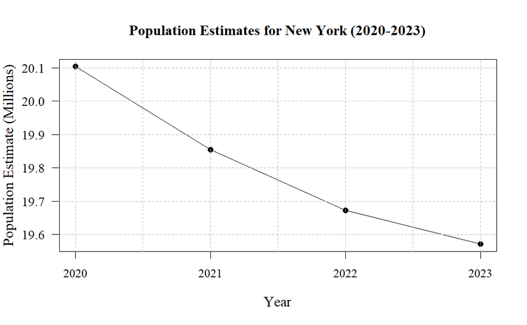

```r
grid(nx = NULL, ny = NULL, lty = 2, col = "gray")
```

```r
NA
NA
```

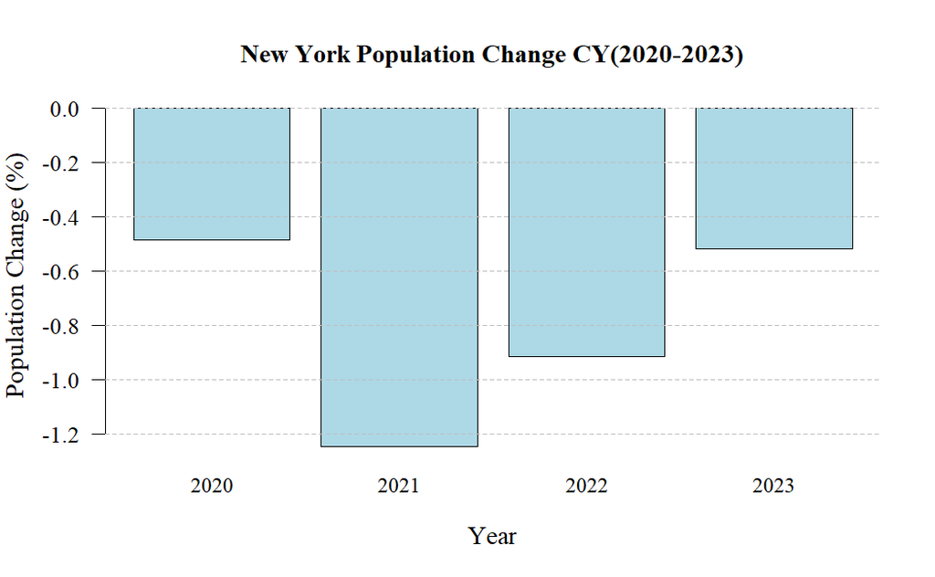

```r
windowsFonts(A = windowsFont("Times New Roman"))
par(family = "A", las = 1)

pop_change <- c(ny_pop_data$PPOPCHG_2020, ny_pop_data$PPOPCHG_2021, ny_pop_data$PPOPCHG_2022, ny_pop_data$PPOPCHG_2023)

# reverse bar chart - for flavor
barplot(pop_change, names.arg = years, col = "lightblue", xlab = "Year",
        ylab = "Population Change (%)", main = "New York Population Change CY(2020-2023)",
        cex.axis = 1.1, cex.lab = 1.2)

grid(nx = NA, ny = NULL, lty = 2, col = "gray")
```

```r
NA
NA
NA
```

# DATASET 5 - New York State Tax Projections

Source: New York State Department of Finance Manual Entry https://www.tax.ny.gov/research/stats/statistics/stat_fy_collections.htm

```r
library(readr)


file_path <- "C:/Users/Ryane/Proton Drive/R Project Files/NYS_tax_revenues_2015-2023.csv"
ny_tax_data <- read.csv(file_path)

colnames(ny_tax_data) <- c(
  "fiscal_year",
  "total_collection",
  "personal_income",
  "corporation_business",
  "sales_excise_user",
  "property_transfers",
  "other_taxes_fees"
)
```

```r
ny_tax_data$total_collection <- as.numeric(gsub("[^0-9.]", "", ny_tax_data$total_collection))
ny_tax_data$personal_income <- as.numeric(gsub("[^0-9.]", "", ny_tax_data$personal_income))
ny_tax_data$corporation_business <- as.numeric(gsub("[^0-9.]", "", ny_tax_data$corporation_business))
ny_tax_data$sales_excise_user <- as.numeric(gsub("[^0-9.]", "", ny_tax_data$sales_excise_user))
ny_tax_data$property_transfers <- as.numeric(gsub("[^0-9.]", "", ny_tax_data$property_transfers))
ny_tax_data$other_taxes_fees <- as.numeric(gsub("[^0-9.]", "", ny_tax_data$other_taxes_fees))
```

```r
str(ny_tax_data)
```

```
'data.frame':   9 obs. of  7 variables:
 $ fiscal_year         : int  2023 2022 2021 2020 2019 2018 2017 2016 2015
 $ total_collection    : num  1.09e+11 1.19e+11 8.04e+10 8.08e+10 7.37e+10 ...
 $ personal_income     : num  5.88e+10 7.07e+10 5.50e+10 5.37e+10 4.81e+10 ...
 $ corporation_business: num  2.65e+10 2.60e+10 7.48e+09 7.71e+09 6.83e+09 ...
 $ sales_excise_user   : num  1.95e+10 1.86e+10 1.53e+10 1.70e+10 1.64e+10 ...
 $ property_transfers  : num  3.66e+09 3.03e+09 2.49e+09 2.19e+09 2.20e+09 ...
 $ other_taxes_fees    : num  1.73e+08 1.88e+08 1.81e+08 1.71e+08 1.76e+08 ...
```

```r
summary(ny_tax_data)
```

```
  fiscal_year   total_collection    personal_income     corporation_business
 Min.   :2015   Min.   :6.810e+10   Min.   :4.371e+10   Min.   :4.689e+09
 1st Qu.:2017   1st Qu.:7.163e+10   1st Qu.:4.757e+10   1st Qu.:6.828e+09
 Median :2019   Median :7.600e+10   Median :5.150e+10   Median :7.484e+09
 Mean   :2019   Mean   :8.322e+10   Mean   :5.290e+10   Mean   :1.114e+10
 3rd Qu.:2021   3rd Qu.:8.076e+10   3rd Qu.:5.497e+10   3rd Qu.:7.711e+09
 Max.   :2023   Max.   :1.185e+11   Max.   :7.074e+10   Max.   :2.651e+10
 sales_excise_user   property_transfers  other_taxes_fees
 Min.   :1.453e+10   Min.   :2.146e+09   Min.   :154691000
 1st Qu.:1.524e+10   1st Qu.:2.204e+09   1st Qu.:164317303
 Median :1.575e+10   Median :2.433e+09   Median :172469056
 Mean   :1.635e+10   Mean   :2.561e+09   Mean   :171117926
 3rd Qu.:1.702e+10   3rd Qu.:2.684e+09   3rd Qu.:175570865
 Max.   :1.948e+10   Max.   :3.657e+09   Max.   :187937297
```

```r
View(ny_tax_data)
```

```r
windowsFonts(A = windowsFont("Times New Roman"))
par(family = "A")

barplot(
  ny_tax_data$total_collection / 1e9,
  names.arg = ny_tax_data$fiscal_year,
  col = "lightblue",
  xlab = "Fiscal Year",
  ylab = "Total State Collections (in billions USD)",
  main = "New York State Total Tax Revenues by FY(2015-2023)",
  las = 1,
  ylim = c(0, max(ny_tax_data$total_collection / 1e9) * 1.1)
)


grid(nx = NA, ny = NULL, col = "gray")
```

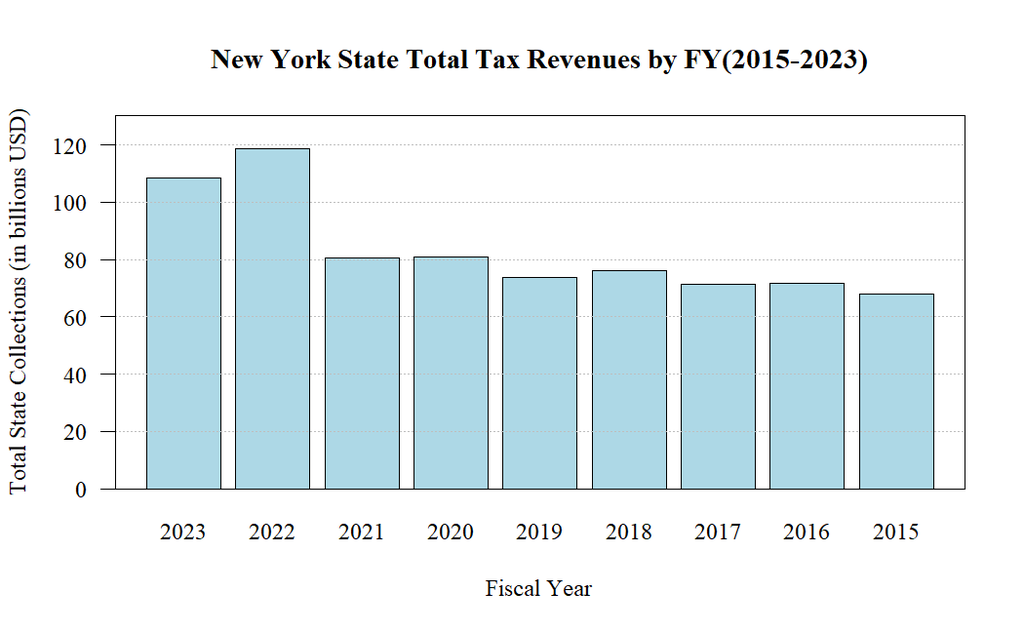

```r
abline(h = seq(20, max(ny_tax_data$total_collection / 1e9), by = 20), col = "gray", lty = "dotted")

box()
```

STEP 2 - MODEL BUILDING

```r
ny_gdp_df
ny_unemployment
ne_cpi_data
ny_tax_data

ny_pop_data$POPESTIMATE2020 <- as.numeric(ny_pop_data$POPESTIMATE2020)
ny_pop_data$POPESTIMATE2021 <- as.numeric(ny_pop_data$POPESTIMATE2021)
ny_pop_data$POPESTIMATE2022 <- as.numeric(ny_pop_data$POPESTIMATE2022)
ny_pop_data$POPESTIMATE2023 <- as.numeric(ny_pop_data$POPESTIMATE2023)

ny_pop_data$PPOPCHG_2020 <- as.numeric(ny_pop_data$PPOPCHG_2020)
ny_pop_data$PPOPCHG_2021 <- as.numeric(ny_pop_data$PPOPCHG_2021)
ny_pop_data$PPOPCHG_2022 <- as.numeric(ny_pop_data$PPOPCHG_2022)
ny_pop_data$PPOPCHG_2023 <- as.numeric(ny_pop_data$PPOPCHG_2023)
```